# It’s a thrill to hike up the hill

Viola Nguyen, Heidi Tsang

12 kwietnia 2019

MacLeish Field Station is located in West Whately, Massachusetts, about 11 miles from the Smith campus. It’s 260 acres area allows students to conduct environmental research ( f.ex. working on Hemlock trees), do outdoor activities and archery. The process of developing Macleish Field Station started in 2008, that is when design studio students worked with Bertone-Johnson to design an interpretive trail network. Although the trails were clered, none of them were classified in terms of difficulty.

In this project [^1] our group is trying to determining the trail difficulty levels at the Macleish Field Station based on their length and change in elevation.

```r
# Loading libraries ----
library(macleish)
library(sf)
library(raster)
library(dplyr)
library(leaflet)
library(ggplot2)
library(rgdal)
library(rgeos)
library(TTR)
library(tidyr)
library(purrr)
library(tidyverse)
```

```r
# Loading macleish layers ----
data("macleish_layers")
class(macleish_layers)
```

```
## [1] "list"
```

```r
# Trails subdataset ----
trail_points <- (macleish_layers[['trails']])
```

```r
# Elevation subdataset ----
elevation <- (macleish_layers[["contours_3m"]])
```

```r
# Western Loop subdata set ----
west_loop<-trail_points%>%
  dplyr::select(name,geometry)%>%
  filter(name=="Western Loop")
```

```r
# Poplar Road subdata set ----
poplar_road<-trail_points%>%
  dplyr::select(name,geometry)%>%
  filter(name=="Poplar Hill Road")
```

```r
# East Loop subdata set ----
east_loop<-trail_points%>%
  dplyr::select(name,geometry)%>%
  filter(name=="Eastern Loop")
```

```r
# Joining Trails with elevation data ----

x <- st_intersection(
  pluck(macleish_layers, "trails"),
  pluck(macleish_layers, "contours_3m")
)
```

```r
# Casting Western Loop ----
western <- filter(x, name == "Western Loop")
western_pts <- western %>%
  st_cast("MULTIPOINT") %>%
  st_cast("POINT")
```

```r
# Casting Poplar Rd ----
poplar <- filter(x, name == "Poplar Hill Road")
poplar_pts <- poplar %>%
  st_cast("MULTIPOINT") %>%
  st_cast("POINT")
```

```r
# Casting Eastern Loop ----
eastern <- filter(x, name == "Eastern Loop")
eastern_pts <- eastern %>%
  st_cast("MULTIPOINT") %>%
  st_cast("POINT")
```

```r
# Creating interactive map ----
leaflet() %>%
  addTiles() %>%
  addPolylines(data=west_loop, color='blue', group='Hiking routes')%>%
   addPolylines(data=east_loop, color='red', group='Hiking routes')%>%
  addPolylines(data=poplar_road, color='purple', group='Hiking routes')%>%
 addMeasure(activeColor="yellow")%>%
  addProviderTiles("Thunderforest.Landscape", group = "Topographical") %>%
  addProviderTiles("Esri.WorldImagery", group = "Satellite")%>%

#Adding legend
    addLegend (position = 'bottomright',opacity = 0.4,
            colors = c('blue','red','purple'),
            labels = c('Western Loop', 'East Loop','Poplar Road'),
            title = 'Hike trails, Macleish Field')%>%

# Layers control
  addLayersControl(position = 'bottomleft',
    baseGroups = c("Topographical", "Road map", "Satellite"),
    overlayGroups = c("Hiking routes"),
    options = layersControlOptions(collapsed = FALSE))
```

[interactive chart not shown]

```r
# Trabsfrming Projections ----
st_transform(trail_points, 4326)
```

```
## Simple feature collection with 15 features and 2 fields
## geometry type:  LINESTRING
## dimension:      XY
## bbox:           xmin: -72.68513 ymin: 42.44177 xmax: -72.67731 ymax: 42.4618
## epsg (SRID):    4326
## proj4string:    +proj=longlat +datum=WGS84 +no_defs
## First 10 features:
##                name  color                       geometry
## 1   Porcupine Trail  White LINESTRING (-72.68291 42.45...
## 2      Western Loop    Red LINESTRING (-72.68111 42.45...
## 3  Poplar Hill Road   Road LINESTRING (-72.68155 42.45...
## 4  Vernal Pool Loop Yellow LINESTRING (-72.68265 42.44...
## 5      Eastern Loop   Blue LINESTRING (-72.68113 42.45...
## 6      Western Loop    Red LINESTRING (-72.68401 42.45...
## 7      Western Loop    Red LINESTRING (-72.68088 42.44...
## 8       entry trail      - LINESTRING (-72.68088 42.44...
## 9      Eastern Loop   Blue LINESTRING (-72.68063 42.45...
## 10         Easy Out    Red LINESTRING (-72.67962 42.45...
```

```r
st_transform(elevation, 4326)
```

```
## Simple feature collection with 125 features and 7 fields
## geometry type:  GEOMETRY
## dimension:      XY
## bbox:           xmin: -72.68712 ymin: 42.44297 xmax: -72.67247 ymax: 42.45884
## epsg (SRID):    4326
## proj4string:    +proj=longlat +datum=WGS84 +no_defs
## First 10 features:
##     OBJECTID Shape_Leng Shape_Area ELEV_M ELEV_FT INDEX_ARC SHAPE_LEN
## 1          1   5893.578    1033988    276     905         N  911.9156
## 1.1        1   5893.578    1033988    267     875         N 1726.6292
## 1.2        1   5893.578    1033988    225     738         Y 1322.5975
## 1.3        1   5893.578    1033988    228     748         N 1896.5112
## 1.4        1   5893.578    1033988    204     669         N 1898.0128
## 1.5        1   5893.578    1033988    243     797         N 1011.1193
## 1.6        1   5893.578    1033988    216     708         N  649.5489
## 1.7        1   5893.578    1033988    192     629         N 1897.5039
## 1.8        1   5893.578    1033988    243     797         N  943.6032
## 1.9        1   5893.578    1033988    264     866         N 1895.3306
##                           geometry
## 1   MULTILINESTRING ((-72.68022...
## 1.1 MULTILINESTRING ((-72.67965...
## 1.2 LINESTRING (-72.67814 42.44...
## 1.3 LINESTRING (-72.6764 42.450...
## 1.4 MULTILINESTRING ((-72.67336...
## 1.5 LINESTRING (-72.67803 42.45...
## 1.6 LINESTRING (-72.6763 42.454...
## 1.7 LINESTRING (-72.67539 42.44...
## 1.8 LINESTRING (-72.68226 42.44...
## 1.9 MULTILINESTRING ((-72.67946...
```

```r
# Total Elevation Gain for Western Loop
western_pts2<-western_pts %>%
  summarize(num_segments = n(),
            total_length = sum(SHAPE_LEN)) %>%
  arrange(desc(total_length))
```

```r
# Total Elevation Gain for Eastern Loop ----
eastern_pts2<-eastern_pts %>%
  summarize(num_segments = n(),
            total_length = sum(SHAPE_LEN)) %>%
  arrange(desc(total_length))
```

```r
# Total Elevation Gain for Poplar Road ----
poplar_pts2<-poplar_pts %>%
  summarize(num_segments = n(),
            total_length = sum(SHAPE_LEN)) %>%
  arrange(desc(total_length))
```

```r
# Calculating Hiking Difficulty ----
# Square root of(Elevation Gain x 2 x distance)
# Distance obtained from interactive map

# Western Loop
west_level<-sqrt(45746.1*2*1.3)

#Eastern Loop
east_level<-sqrt(56482.79*2*1.16)

#Poplar Hill Road
poplar_level<-sqrt(17165.42*2*0.65)

# Hiking difficulty for each trail (in order)
east_level #Eastern Loop
```

```
## [1] 361.9946
```

```r
west_level # Western Loop
```

```
## [1] 344.8766
```

```r
poplar_level #Poplar Hill Road
```

```
## [1] 149.3822
```

```r
# Filtering subset to use in creating difficulty grade function ----
everything <- x %>%
  dplyr::select("name", "ELEV_M", "SHAPE_LEN") %>%
  st_set_geometry(NULL)
```

```r
# Creating function to plot graphs for each trail ----
difficulty_grade <- function(trail_name) {

  everything %>%
    filter(name == trail_name) %>%
    ggplot(aes(x = SHAPE_LEN, y = ELEV_M)) +
 geom_smooth(method = 'loess') +
  geom_point(size = 5) +
  geom_smooth(color = "black") +
    labs(title = trail_name)+
    xlab("Distance of Trail (miles)") +
  ylab("Change in elevation (ft)")
}
```

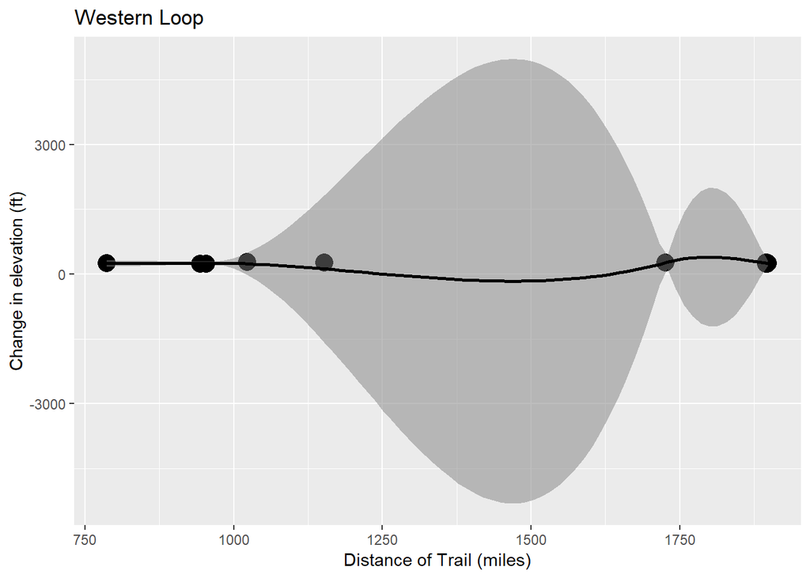

```r
# Function execution ----
difficulty_grade("Western Loop")
```

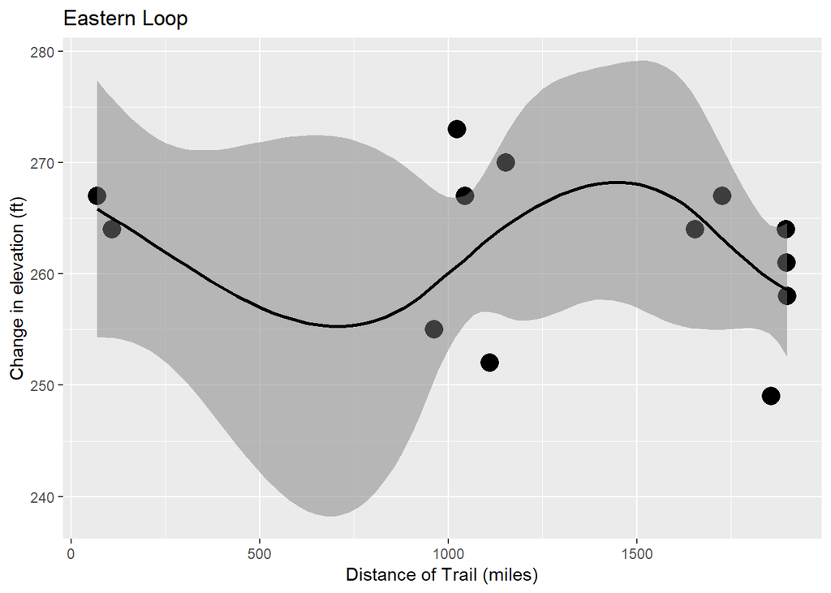

```r
difficulty_grade("Eastern Loop")
```

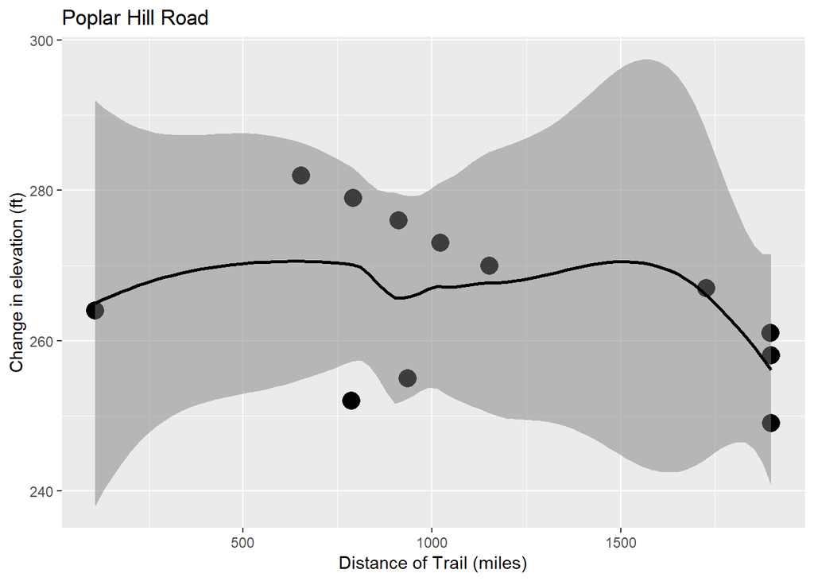

```r
difficulty_grade("Poplar Hill Road")
```

To determine the difficulty level we used the following formula from [NPS Website](https://www.nps.gov/shen/planyourvisit/how-to-determine-hiking-difficulty.htm) : Square root of ( Elevation Gain(in feet) x 2 x distance (in miles))

*Recommendations* To advertise the MacLeish station, we recommend opening the MacLeish Station for the public, not just the Smith students. The trails should be clearly labeled with the difficulty level and suggestions on what age range is appropriate for which trail. Good way to advertise Macleish Field is to record commercial that could encourage general public, prospective students as well as current students to take advantage of MacLeish Station.

*1. What will it cost?* The commercial / teaser should be recorder by Smith students in order to save on costs of the production. If the project would be entirely curated by students, the costs of the production would be close to zero.

*2. How long will it take* This should take about a week depending on how many people are working on it.

*4. Do you see any major roadblocks?* Opening to public may interfere with any on going research taking place at MacLeish because of traffic.

[^1]: Mini project 3 was uploaded and edited via Github repository [link](https://github.com/tsa-heidi/MP3-SDS192.git)